# Visualizing geospatial data in R

Author

Rick Dean

Abstract

The following R script was inspired by an article [Visualizing geospatial data in R](https://www.r-bloggers.com/2020/11/visualizing-geospatial-data-in-r-part-1-finding-loading-and-cleaning-data/) posted November 24, 2020 by Nathaniel Schmucker in R bloggers. This is part 1 of a 3 part series.

- Article setup:
  - Install `quarto` executable from <https://quarto.org>
- To compile article inside RStudio:
  - open file `Part_1_finding_loading_cleaning_data.qmd`
  - press `Render` from a recent version of RStudio
- For a table of contents, set the yaml line `toc:` to true and re-render.

# 1 Part 1: Finding, loading, and cleaning data

Load the Required R Packages.

```r
library(here, quietly = T)
library(data.table, quietly = T)
library(purrr)
library(gt, quietly = T)
library(magrittr, quietly = T)
library(leaflet, quietly = T)
library(ggplot2, quietly = T)
library(sf, quietly = T)
library(usmap, quietly = T)
library(rnaturalearth, quietly = T)
library(RplotterPkg, quietly = T)
library(RspatialPkg, quietly = T)
library(RcensusPkg, quietly = T)
```

Define the file path to the shapefiles folder at the root of this Rstudio project for holding downloaded shapefiles:

```r
shapefile_directory <- file.path(here(), "shapefiles")
```

## 1.1 Introduction

> If you want to draw state borders (polygons), county borders (more polygons), major highways (lines), and highway rest stops (points), add each of them as an individual layer to the same plot, and color them as you please. There are no constraints when visualizing geospatial data in R.

> This post will focus on how to find, import, and clean geospatial data. The actual graphing will come in Part 2 (static maps with ggplot2) and Part 3 (interactive maps with leaflet).

## 1.2 A brief introduction to simple features data in R

> Out in the wild, map data most frequntly comes as either geoJSON files (.geojson) or Shapefiles (.shp). These files will, at the very minimum, contain information about the geometry of each object to be drawn, such as instructions to draw a point in a certain location or to draw a polygon with certain dimensions. The raw file may, however, also contain any amount of additional information, such as a name for the object (“Pennsylvania”), or summary statistics (GDP per capita, total population, etc.).

Read raw shapefile data from “OpenDataPhilly”.

```r
zip_geojson <- "http://data.phl.opendata.arcgis.com/datasets/b54ec5210cee41c3a884c9086f7af1be_0.geojson"
phl_zip_raw_sf <- sf::read_sf(zip_geojson)
```

Looking at the data…

```r
head(phl_zip_raw_sf)
```

```
Simple feature collection with 6 features and 5 fields
Geometry type: POLYGON
Dimension:     XY
Bounding box:  xmin: -75.20435 ymin: 39.95577 xmax: -75.06099 ymax: 40.05317
Geodetic CRS:  WGS 84
# A tibble: 6 × 6
  OBJECTID CODE    COD Shape__Area Shape__Length                        geometry
     <int> <chr> <int>       <dbl>         <dbl>                   <POLYGON [°]>
1        1 19120    20   91779697.        49922. ((-75.11107 40.04682, -75.1094…
2        2 19121    21   69598787.        39535. ((-75.19227 39.99463, -75.1920…
3        3 19122    22   35916319.        24125. ((-75.15406 39.98601, -75.1532…
4        4 19123    23   35851751.        26422. ((-75.1519 39.97056, -75.1515 …
5        5 19124    24  144808025.        63659. ((-75.0966 40.04249, -75.09281…
6        6 19125    25   48226254.        30114. ((-75.10849 39.9703, -75.11051…
```

> We are told the Coordinate Reference System (CRS), which in this case is “WGS 84.” CRSs are cartographers’ ways of telling each other what system they used for describing points on the earth. Cartographers need to pick an equation for an ellipsoid to approximate earth’s shape since it’s slightly pear-shaped. Cartographers also need to determine a set of reference markers–known as a datum–to use to set coordinates, as earth’s tectonic plates shift ever so slightly over time. Togehether, the ellipsoid and datum become a CRS.

> WGS 84 is one of the most common CRSs and is the standard used for GPS applications. In the US, you may see data provided using NAD 83. WGS 84 and NAD 83 were originally identical (back in the 1980s), but both have been modified over time as the earth changes and scientific knowledge progresses. WGS 84 seeks to keep the global average of points as similar as possible while NAD 83 tries to keep the North American plate as constant as possible. The net result is that the two different CRSs may vary by about a meter in different places. This is not a big difference for most purposes, but sometimes you may need to adjust.

> If we wanted to transform our data between CRSs, we would call `sf::st_transform(map_raw, crs = 4326)`, where 4362 is the EPSG code of the CRS into which we would like to transform our geometry. EPSGs are a standard, shorthand way to refer to various CRSs. 4326 is the EPSG code for WGS 84 and 4269 is the EPSG code for NAD 83.

## 1.3 Finding data

> The trouble comes in trying to find the data you need–both the geometry and the proper additional fields–and getting them together into the same object in R.

### 1.3.1 Finding geospatial data

Import US Census Bureau county data from Pennsylvania.

```r
penn_fips <- usmap::fips(state = "pennsylvania")
express <- expression(STATEFP == penn_fips)
penn_cty_sf <- RcensusPkg::tiger_counties_sf(
  output_dir = shapefile_directory,
  vintage = 2018,
  general = TRUE,
  resol = "20m",
  express = express,
  sf_info = FALSE
) %>%
  data.table::as.data.table(.) %>%
  .[, .(GEOID, NAME, COUNTYFP, COUNTYNS, geometry)] %>%
  .[, NAME := toupper(NAME)] %>%
  data.table::setnames(., old = "NAME", new = "COUNTY") %>%
  sf::st_as_sf(.)
```

Look at `penn_cty_sf`:

```r
head(penn_cty_sf)
```

```
Simple feature collection with 6 features and 4 fields
Geometry type: MULTIPOLYGON
Dimension:     XY
Bounding box:  xmin: -80.51971 ymin: 40.18536 xmax: -76.11517 ymax: 42.00072
Geodetic CRS:  NAD83
  GEOID   COUNTY COUNTYFP COUNTYNS                       geometry
1 42113 SULLIVAN      113 01213687 MULTIPOLYGON (((-76.81373 4...
2 42015 BRADFORD      015 01213660 MULTIPOLYGON (((-76.92685 4...
3 42099    PERRY      099 01213682 MULTIPOLYGON (((-77.67176 4...
4 42035  CLINTON      035 01214721 MULTIPOLYGON (((-78.09338 4...
5 42075  LEBANON      075 01214034 MULTIPOLYGON (((-76.67804 4...
6 42007   BEAVER      007 01214112 MULTIPOLYGON (((-80.51971 4...
```

Map the Pennsylvania counties:

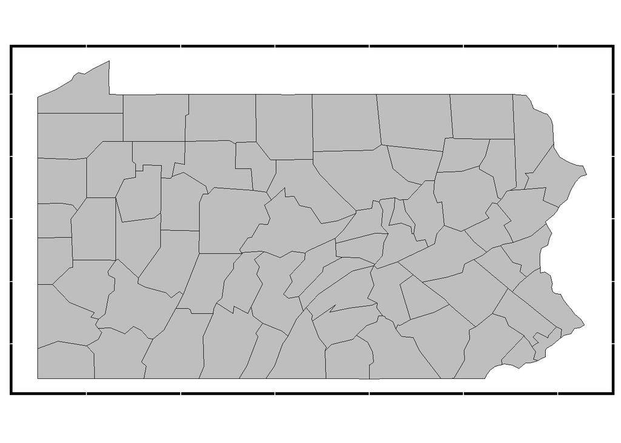

Basic map of PA counties, Source: U.S. Census Bureau TIGER/Line Shapefiles.

```r
RspatialPkg::get_geom_sf(
  sf = penn_cty_sf,
  hide_x_tics = T,
  hide_y_tics = T
)
```

For non-US applications, use the package `rnaturalearth` which provides easy access to global data.

```r
asia_sf <- rnaturalearth::ne_countries(
  continent = "Asia",
  returnclass = "sf"
)
```

Look at `asia_sf`:

```r
head(asia_sf, 0)
```

```
Simple feature collection with 0 features and 63 fields
Bounding box:  xmin: NA ymin: NA xmax: NA ymax: NA
CRS:           +proj=longlat +datum=WGS84 +no_defs +ellps=WGS84 +towgs84=0,0,0
 [1] scalerank  featurecla labelrank  sovereignt sov_a3     adm0_dif
 [7] level      type       admin      adm0_a3    geou_dif   geounit
[13] gu_a3      su_dif     subunit    su_a3      brk_diff   name
[19] name_long  brk_a3     brk_name   brk_group  abbrev     postal
[25] formal_en  formal_fr  note_adm0  note_brk   name_sort  name_alt
[31] mapcolor7  mapcolor8  mapcolor9  mapcolor13 pop_est    gdp_md_est
[37] pop_year   lastcensus gdp_year   economy    income_grp wikipedia
[43] fips_10    iso_a2     iso_a3     iso_n3     un_a3      wb_a2
[49] wb_a3      woe_id     adm0_a3_is adm0_a3_us adm0_a3_un adm0_a3_wb
[55] continent  region_un  subregion  region_wb  name_len   long_len
[61] abbrev_len tiny       homepart   geometry
<0 rows> (or 0-length row.names)
```

Map `asia_sf`:

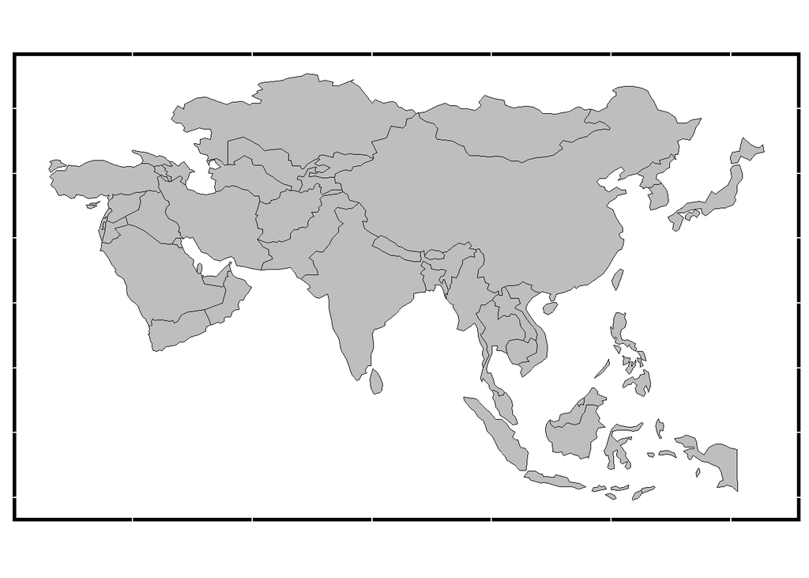

Basic map of countries in Asia. Source: rnaturalearth package.

```r
RspatialPkg::get_geom_sf(
  sf = asia_sf,
  hide_x_tics = T,
  hide_y_tics = T
)
```

### 1.3.2 Finding non-geospatial data

> Chances are that you are coming to a geospatial mapping project with a particular dataset in mind.

> …Hopefully, your data has an ID that you can use to identify each geospatial region.

Join PA’s Department of Health hospital data with PA’s county geometries.

1. Read the source data:

```r
pa_hospitals_csv_path <- file.path(here(), "data", "DOH_Hospitals201912.csv")
pa_hospitals_raw_dt <- data.table::fread(file = pa_hospitals_csv_path) %>%
  .[, .(FACILITY_N,COUNTY)] %>%
  .[, COUNTY := trimws(COUNTY)]
```

2. Group `pa_hospitals_raw_dt` by “COUNTY” and create a column with the number of facilities:

```r
pa_hospitals_grouped_dt <- pa_hospitals_raw_dt[, .(N_Facility = .N), by = COUNTY] %>%
  .[order(COUNTY),]
head(pa_hospitals_grouped_dt)
```

```
      COUNTY N_Facility
1:     ADAMS          1
2: ALLEGHENY         28
3: ARMSTRONG          1
4:    BEAVER          2
5:   BEDFORD          1
6:     BERKS          6
```

3. Get the PA county populations from the US Census Bureau:

```r
pa_cty_pop_dt <- RcensusPkg::get_vintage_data(
  dataset = "dec/pl",
  vintage = 2020,
  vars = "P1_001N",
  region = "county:*",
  regionin = paste0("state:", penn_fips)
) %>%
  .[, .(GEOID, NAME, P1_001N)] %>%
  .[, c("COUNTY", "State_str") := tstrsplit(NAME, "County,")] %>%
  .[, COUNTY := trimws(toupper(COUNTY))] %>%
  data.table::setnames(., old = "P1_001N", new = "Cty_Pop") %>%
  .[, .(COUNTY, Cty_Pop)] %>%
  .[order(COUNTY),]
head(pa_cty_pop_dt)
```

```
      COUNTY Cty_Pop
1:     ADAMS  103852
2: ALLEGHENY 1250578
3: ARMSTRONG   65558
4:    BEAVER  168215
5:   BEDFORD   47577
6:     BERKS  428849
```

4. Join the values of `pa_hospitals_grouped_dt` with `pa_cty_pop_dt` using their common variable “COUNTY”:

```r
data.table::setkeyv(pa_hospitals_grouped_dt, "COUNTY")
data.table::setkeyv(pa_cty_pop_dt, "COUNTY")

pa_hospitals_pop_dt <- pa_cty_pop_dt[pa_hospitals_grouped_dt] %>%
  .[, `:=`(Cty_Pop = as.numeric(Cty_Pop))]
head(pa_hospitals_pop_dt)
```

```
      COUNTY Cty_Pop N_Facility
1:     ADAMS  103852          1
2: ALLEGHENY 1250578         28
3: ARMSTRONG   65558          1
4:    BEAVER  168215          2
5:   BEDFORD   47577          1
6:     BERKS  428849          6
```

5. Add a column to the joined data.table `pa_hospitals_pop_dt` that divides “N_Facility” by “Cty_Pop”:

```r
pa_hospitals_pop_dt[, Hosp_Per_1M := N_Facility / (Cty_Pop/1000000)]
head(pa_hospitals_pop_dt)
```

```
      COUNTY Cty_Pop N_Facility Hosp_Per_1M
1:     ADAMS  103852          1    9.629088
2: ALLEGHENY 1250578         28   22.389647
3: ARMSTRONG   65558          1   15.253669
4:    BEAVER  168215          2   11.889546
5:   BEDFORD   47577          1   21.018559
6:     BERKS  428849          6   13.990939
```

6. Join the county geometries with the hospital data:

```r
pa_hospitals_pop_dt <- RcensusPkg::join_it(
  df_1 = pa_hospitals_pop_dt,
  df_2 = penn_cty_sf,
  key_1 = "COUNTY",
  key_2 = "COUNTY"
)
```

7. Map the geometries and hospital data:

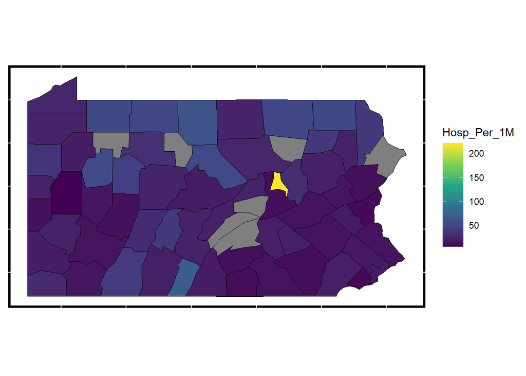

Hospitals per million residents. Montour County is apparently the place to be if you need a hospital!

```r
RspatialPkg::get_geom_sf(
  sf = sf::st_as_sf(pa_hospitals_pop_dt),
  aes_fill = "Hosp_Per_1M",
  hide_x_tics = T,
  hide_y_tics = T,
  legend_key_width = 0.7,
  legend_key_height = 0.7
) +
  ggplot2::scale_fill_viridis_c()
```

This concludes notes on Part 1 of “Visualizing geospatial data in R”.